# Tidy data loading, labelling, summarizing

Margaret Janiczek

2022-12-02

Data is downloaded from: https://thisisstatistics.org/falldatachallenge/.

Details on the dataset and prompt [here](https://docs.google.com/document/d/1qXnbS4fjuQ9hbRxGaSmix3CGb3FUi6U5/edit)

[Full 2019 codebook describing data](https://nces.ed.gov/nhes/data/2019/pfi/cbook_pfi_pu.pdf)

[Curated dataset codebook (for just the 75 variables in the dataset)](https://docs.google.com/spreadsheets/d/1X7fDKA_BZjSDwUCIo_3fax1viY1_wcJH/edit?usp=sharing&ouid=108879154306217142702&rtpof=true&sd=true)

# 1 Load data and libraries

Load libraries

```r
#install.packages("gtsummary", "labelled", "tidyverse")
library(tidyverse)
library(labelled)
library(gtsummary)
```

Load data, make sure either file in same folder as your Rmd or specify correct path.

```r
dat <- readxl::read_xlsx("2022 Fall Data Challenge Dataset.xlsx")
```

Select a few variables to work with

```r
dat_small <- dat %>%
  select(SEENJOY, SEGRADES, FHWKHRS, FCSCHOOL, ALLGRADEX)
```

# 2 Summarize data and check for missingness

```r
summary(dat_small)
```

```
##     SEENJOY          SEGRADES         FHWKHRS          FCSCHOOL
##  Min.   :-1.000   Min.   :-1.000   Min.   :-1.000   Min.   :-1.000
##  1st Qu.: 1.000   1st Qu.: 1.000   1st Qu.: 2.000   1st Qu.: 1.000
##  Median : 2.000   Median : 2.000   Median : 4.000   Median : 1.000
##  Mean   : 1.766   Mean   : 2.004   Mean   : 5.358   Mean   : 1.436
##  3rd Qu.: 2.000   3rd Qu.: 2.000   3rd Qu.: 7.000   3rd Qu.: 2.000
##  Max.   : 4.000   Max.   : 5.000   Max.   :75.000   Max.   : 4.000
##    ALLGRADEX
##  Min.   : 2.000
##  1st Qu.: 6.750
##  Median :10.000
##  Mean   : 9.613
##  3rd Qu.:13.000
##  Max.   :15.000
```

Now I notice some negative levels so I went to the detailed code book and found that means “Valid skip”.

I will recode those to be “NA” before deciding what to do with them. You can choose what to do with missing data - impute or exclude.

```r
dat_small[dat_small== -1] <- NA
```

# 3 Make categorical variables into factors

According to code book several of these are categorical variables so we need to recode them so R doesn’t interpret them as numeric. Here’s a way to do that in bulk, basically either just select all the ones you want categorical or deselect the continuous ones.

```r
# Here I'm mutated across all columns EXCEPT the continuous "FHWKHRS" and making them factor variables

dat_new <- dat_small %>%
  mutate(
    across(
      .cols = !c(FHWKHRS), as.factor
    )
  ) %>%
  drop_na() # for now excluding missing observations

# check on how that did
summary(dat_new)
```

```
##  SEENJOY  SEGRADES    FHWKHRS       FCSCHOOL   ALLGRADEX
##  1:5353   1:7308   Min.   : 0.000   1:9217   15     :1494
##  2:7519   2:4159   1st Qu.: 2.000   2:4428   13     :1429
##  3:1292   3:1166   Median : 5.000   3: 592   14     :1410
##  4: 289   4: 198   Mean   : 5.819   4: 216   12     :1223
##           5:1622   3rd Qu.: 8.000            11     :1184
##                    Max.   :75.000            10     :1151
##                                              (Other):6562
```

# 4 Collapse a categorical variable

Let’s make a new categorical variable based on “ALLGRADEX”, where we collapse into Elementary, Middle, High school, College. Also I am making a new “SEENJOY”

```r
#collapse factors manually into groups
dat_new2 <- dat_new %>%
  mutate(gradelevel = fct_collapse(ALLGRADEX,
           Elementary = c("2", "3", "4", "5"),
           Middle = c("6", "7", "8"),
           High = c("9", "10", "11", "12"),
           College = c("13", "14", "15")),
          SEENJOY2 = fct_collapse(SEENJOY,
      Yes = c("3", "4"),
      No = c("1", "2")))

summary(dat_small$ALLGRADEX)
```

```
##    Min. 1st Qu.  Median    Mean 3rd Qu.    Max.
##   2.000   6.750  10.000   9.613  13.000  15.000
```

```r
summary(dat_small$gradelevel)
```

```
## Length  Class   Mode
##      0   NULL   NULL
```

Okay now lets get rid of that ALLGRADEX variable going forward.

```r
dat_new2 <- dat_new2 %>% select(-c(ALLGRADEX, SEENJOY))
```

# 5 Labeling variables and factor levels

For presentation purposes it is often useful to label your variables and factor levels.

Now lets label the levels using the `forcats` package.

```r
# first make named vectors for the level labels

fcschool_labels <- c(
  "Very satisfied" ="1",
   "Somewhat satisfied" = "2",
   "Somewhat dissatisfied" = "3",
   "Very dissatisfied" = "4"
)

# seenjoy_labels <- c(
#   "Strongly agree" = "1",
#   "Agree" = "2",
#   "Disagree" = "3",
#   "Strongly Disagree" = "4"
# )

segrades_labels <- c(
  "Mostly A's" = "1",
  "Mostly B's" = "2",
  "Mostly C's" = "3",
  "Mostly D's or lower" = "4",
  "School does not give these grades" = "5"
)

#making new dataframe so we can see difference
dat_new3 <- dat_new2 %>%
  mutate(
    FCSCHOOL = fct_recode(FCSCHOOL, !!!fcschool_labels),
    #SEENJOY = fct_recode(SEENJOY, !!!seenjoy_labels),
    SEGRADES = fct_recode(SEGRADES, !!!segrades_labels)
  )
```

And label the column titles using the `labelled` packages.

```r
var_labels <- c(
  #SEENJOY = "Enjoyment of school",
  SEGRADES = "Grades",
  FHWKHRS = "Hours spent doing homework",
  FCSCHOOL = "Satisfaction with school",
  gradelevel = "Grade Level",
  SEENJOY2 = "Enjoyment of school"
)


dat_new3 <- set_variable_labels(dat_new3, .labels = var_labels)
```

# 6 Pretty Table 1

Now we can make a pretty table summarizing the data.

```r
dat_new3 %>%
  tbl_summary(by = gradelevel)
```

| **Characteristic** | **Elementary**, N = 2,548<sup>1</sup> | **Middle**, N = 2,911<sup>1</sup> | **High**, N = 4,661<sup>1</sup> | **College**, N = 4,333<sup>1</sup> |
| --- | --- | --- | --- | --- |
| Grades |  |  |  |  |
| Mostly A's | 1,098 (43%) | 1,395 (48%) | 2,548 (55%) | 2,267 (52%) |
| Mostly B's | 371 (15%) | 821 (28%) | 1,497 (32%) | 1,470 (34%) |
| Mostly C's | 78 (3.1%) | 159 (5.5%) | 443 (9.5%) | 486 (11%) |
| Mostly D's or lower | 17 (0.7%) | 30 (1.0%) | 68 (1.5%) | 83 (1.9%) |
| School does not give these grades | 984 (39%) | 506 (17%) | 105 (2.3%) | 27 (0.6%) |
| Hours spent doing homework | 3.0 (2.0, 5.0) | 4.0 (2.0, 5.0) | 5.0 (3.0, 8.0) | 6.0 (3.0, 10.0) |
| Satisfaction with school |  |  |  |  |
| Very satisfied | 1,873 (74%) | 1,971 (68%) | 2,870 (62%) | 2,503 (58%) |
| Somewhat satisfied | 565 (22%) | 803 (28%) | 1,522 (33%) | 1,538 (35%) |
| Somewhat dissatisfied | 74 (2.9%) | 96 (3.3%) | 197 (4.2%) | 225 (5.2%) |
| Very dissatisfied | 36 (1.4%) | 41 (1.4%) | 72 (1.5%) | 67 (1.5%) |
| Enjoyment of school | 119 (4.7%) | 233 (8.0%) | 539 (12%) | 690 (16%) |

<sup>1</sup> n (%); Median (IQR)

# 7 Initial visualizations

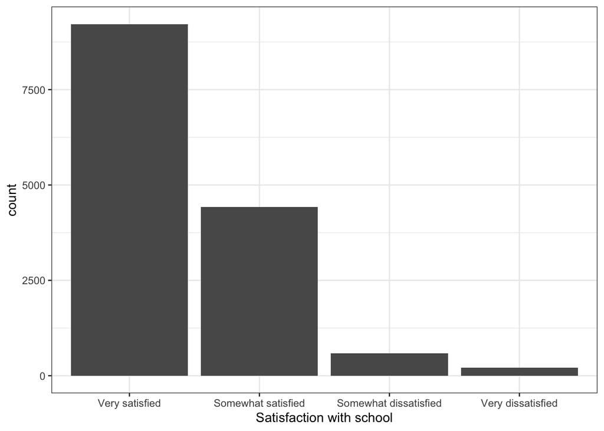

```r
# set ggplot theme
theme_set(theme_bw())

ggplot(dat_new3,
       aes(x = FCSCHOOL)) +
  geom_bar() +
  labs(x = "Satisfaction with school")
```

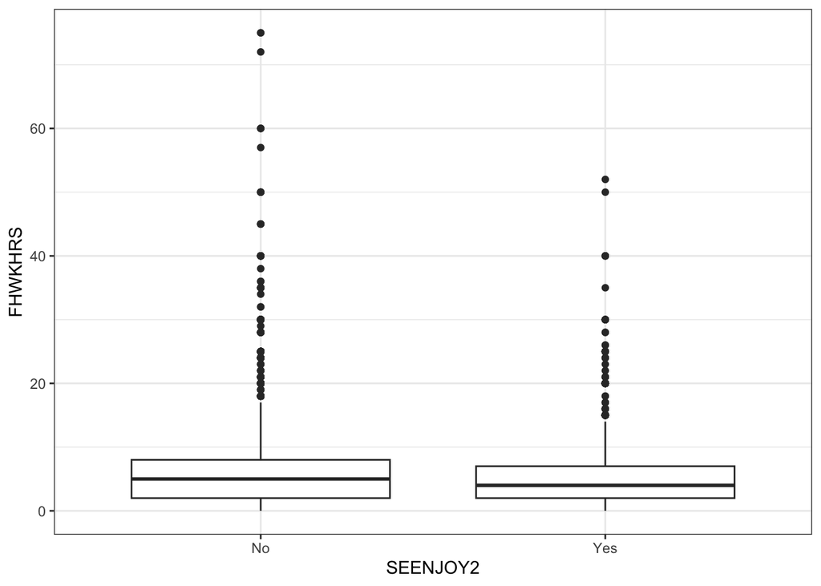

```r
ggplot(
  dat_new3,
  aes(x = SEENJOY2,
      y = FHWKHRS)) +
  geom_boxplot()
```

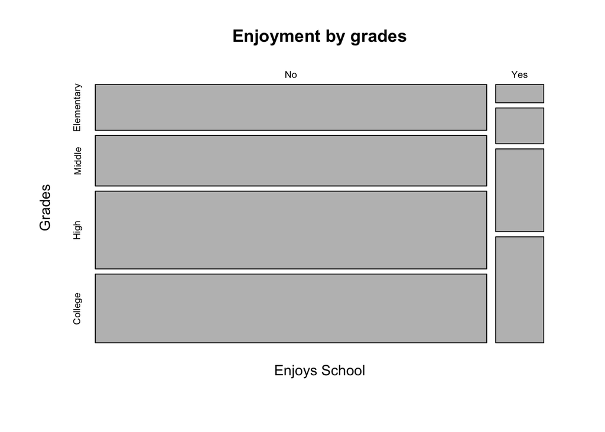

```r
counts <- table(dat_new3$SEENJOY2, dat_new3$gradelevel)
mosaicplot(counts,
           xlab = "Enjoys School",
           ylab = "Grades",
           main = "Enjoyment by grades")
```

# 8 Model summaries using gtsummary

```r
mod1 <- glm(
  SEENJOY2 ~ .,
  data = dat_new3,
  family = "binomial"
)

tbl_regression(mod1, exponentiate = TRUE)
```

| **Characteristic** | **OR**<sup>1</sup> | **95% CI**<sup>1</sup> | **p-value** |
| --- | --- | --- | --- |
| Grades |  |  |  |
| Mostly A's | — | — |  |
| Mostly B's | 1.83 | 1.59, 2.10 | <0.001 |
| Mostly C's | 4.43 | 3.74, 5.24 | <0.001 |
| Mostly D's or lower | 10.8 | 7.76, 15.0 | <0.001 |
| School does not give these grades | 2.16 | 1.69, 2.75 | <0.001 |
| Hours spent doing homework | 0.99 | 0.98, 1.00 | 0.2 |
| Satisfaction with school |  |  |  |
| Very satisfied | — | — |  |
| Somewhat satisfied | 3.12 | 2.75, 3.55 | <0.001 |
| Somewhat dissatisfied | 8.71 | 7.11, 10.6 | <0.001 |
| Very dissatisfied | 14.5 | 10.6, 19.8 | <0.001 |
| Grade Level |  |  |  |
| Elementary | — | — |  |
| Middle | 1.73 | 1.36, 2.22 | <0.001 |
| High | 2.48 | 1.96, 3.16 | <0.001 |
| College | 3.50 | 2.76, 4.46 | <0.001 |

<sup>1</sup> OR = Odds Ratio, CI = Confidence Interval